# Austria Covid Forecast

2022-04-03

## Published Covid case figures in Austria follow a weekly seasonal pattern

Since the pandemic began, COVID figures are omnipresent in our everyday’s life. For data scientists this flood of data must draw attention earlier or later. Especially interesting is the **weekly seasonal pattern** in published cases in Austria: Tuesdays through Thursdays show typically significantly higher case numbers than the other days of the week.

This app shall

1. analyse and highlight this weekly seasonal pattern and
2. use it for a simple 14-day-forecast

The app can be viewed at [Austria Covid Forecast](https://nagrne-boris-blazej.shinyapps.io/covid/)

## First, the app decomposes a training time series …

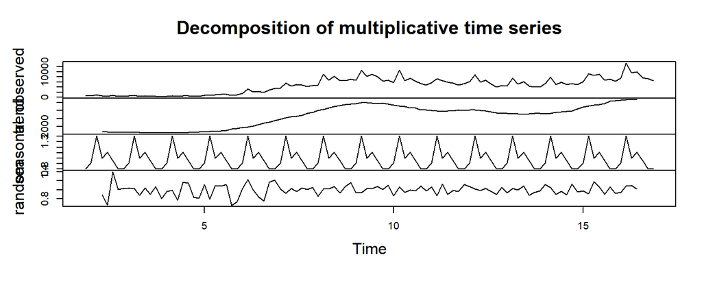

```r
ddata <- decompose(t_series, "multiplicative")

plot(ddata)
```

## … then it uses this to forecast the next 14 days

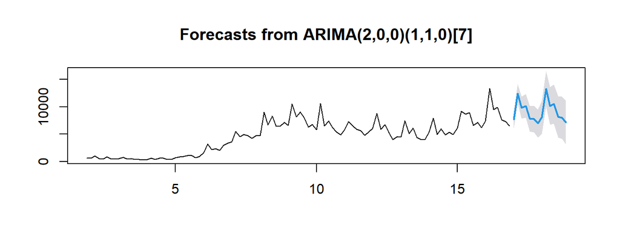

```r
next_2_weeks <- forecast(mymodel, c(95), h = 2 * 7)

plot(next_2_weeks)
```

## Background

### **Input Parameters:**

The forecast uses data up to the **‘final training day’** ranging back **‘number of training weeks’**. One can select either one of the nine Austrian provinces or the total Austrian numbers.

### **Important limitation:**

Since automated data updates (~600kB from [data.gv.at-Open Data Österreich](https://www.data.gv.at/katalog/dataset/ef8e980b-9644-45d8-b0e9-c6aaf0eff0c0)) fail on shinyapps.io there is a dataset available with the app for proper functionality. Please refer to the app (left lower section) for latest update info